# Analysis 1: UNC Salaries

Ishaan Phadnis

September 20, 2019

#Instructions

**Overview:** For each question, show your R code that you used to answer each question in the provided chunks. When a written response is required, be sure to answer the entire question in complete sentences outside the code chunks. When figures are required, be sure to follow all requirements to receive full credit. Point values are assigned for every part of this analysis.

**Helpful:** Make sure you knit the document as you go through the assignment. Check all your results in the created HTML file.

**Submission:** Submit via an electronic document on Sakai. Must be submitted as an HTML file generated in RStudio.

#Introduction

Universities are typically opaque, bureaucratic institutions. To be transparent to tax payers, many public schools, such as the University of North Carolina, openly report **[salary information](http://www.newsobserver.com/news/databases/public-salaries/)**. In this assignment, we will analyze this information to answer pivotal questions that have endured over the course of time. The most recent salary data for UNC-Chapel Hill faculty and staff has already been downloaded in CSV format and titled *“UNC_System_Salaries Search and Report.csv”*. If you scan the spreadsheet, you will notice that Dr. Mario is not listed. People get depressed when they see that many digits after the decimal.

To answer all the questions, you will need the R package `tidyverse` to make figures and utilize `dplyr` functions.

```r
options(scipen=999)
knitr::opts_chunk$set(echo = TRUE)
library(tidyverse)
```

#Data Information

Make sure the CSV data file is contained in the folder of your RMarkdown file. First, we start by using the `read_csv` function from the `readr` package found within the tidyverse. The code below executes this process by creating a tibble in your R environment named “salary”.

```r
salary=read_csv("UNC_System_Salaries Search and Report.csv")
```

Now, we will explore the information that is contained in this dataset. The code below provides the names of the variables contained in the dataset.

```r
names(salary)
```

```
##  [1] "Name"                  "campus2"
##  [3] "dept"                  "position"
##  [5] "PRIMARY_WORKING_TITLE" "hiredate"
##  [7] "exempt"                "fte"
##  [9] "employed"              "statesal"
## [11] "nonstsal"              "totalsal"
## [13] "stservyr"
```

Next, we will examine the type of data contains in these different variables.

```r
str(salary,give.attr=F)
```

```
## Classes 'spec_tbl_df', 'tbl_df', 'tbl' and 'data.frame': 12646 obs. of  13 variables:
##  $ Name                 : chr  "AACHOUI, YOUSSEF" "AARNIO, REA T" "ABAJAS, YASMINA L" "ABARBANELL, JEFFERY S" ...
##  $ campus2              : chr  "UNC-CHAPEL HILL" "UNC-CHAPEL HILL" "UNC-CHAPEL HILL" "UNC-CHAPEL HILL" ...
##  $ dept                 : chr  "Microbiology and Immunology" "SW-Research Projects" "Peds-Hematology/Oncology" "Kenan-Flagler Bus Sch" ...
##  $ position             : chr  "Research Professional, Medical" "Functional Paraprofessional" "Assistant Professor" "Associate Professor" ...
##  $ PRIMARY_WORKING_TITLE: chr  "Research Associate" "Graphic Designer" "NODESCR" "Associate Professor" ...
##  $ hiredate             : chr  "10/10/2011" "1/14/2013" "7/1/2015" "1/1/1999" ...
##  $ exempt               : chr  "Exempt from Personnel Act" "Subject to State Personnel Act" "Exempt from Personnel Act" "Exempt from Personnel Act" ...
##  $ fte                  : num  1 0.8 1 1 1 1 1 1 1 1 ...
##  $ employed             : num  12 12 12 9 12 12 12 9 12 9 ...
##  $ statesal             : logi  NA NA NA NA NA NA ...
##  $ nonstsal             : logi  NA NA NA NA NA NA ...
##  $ totalsal             : num  49128 33257 139405 181000 41098 ...
##  $ stservyr             : num  1 5 2 20 6 8 6 1 19 1 ...
```

You will notice that the variable “hiredate” is recorded as a character. The following code will first modify the original dataset to change this to a date variable with the format *mm/dd/yyyy*. Then, we will remove the hyphens to create a numeric variable as *yyyymmdd*. Finally, in the spirit of tidyverse, we will convert this data frame to a tibble

```r
salary$hiredate=as.Date(salary$hiredate, format="%m/%d/%Y")
salary$hiredate=as.numeric(gsub("-","",salary$hiredate))
salary=as.tibble(salary)
```

Now, we will use `head()` to view of first five rows and the modifications made to the original data. The rest of the assignment will extend off this modified dataset named `salary` which by now should be in your global environment.

```r
head(salary,5)
```

```
## # A tibble: 5 x 13
##   Name  campus2 dept  position PRIMARY_WORKING~ hiredate exempt   fte
##   <chr> <chr>   <chr> <chr>    <chr>               <dbl> <chr>  <dbl>
## 1 AACH~ UNC-CH~ Micr~ Researc~ Research Associ~ 20111010 Exemp~   1
## 2 AARN~ UNC-CH~ SW-R~ Functio~ Graphic Designer 20130114 Subje~   0.8
## 3 ABAJ~ UNC-CH~ Peds~ Assista~ NODESCR          20150701 Exemp~   1
## 4 ABAR~ UNC-CH~ Kena~ Associa~ Associate Profe~ 19990101 Exemp~   1
## 5 ABAR~ UNC-CH~ Inst~ Researc~ Research Techni~ 20110912 Subje~   1
## # ... with 5 more variables: employed <dbl>, statesal <lgl>,
## #   nonstsal <lgl>, totalsal <dbl>, stservyr <dbl>
```

# Assignment

## Part 1: Reducing the Data to a Smaller Set of Interest

###Q1 *(2 Points)*

Create a new dataset named `salary2` that only contains the following variables:

- “Name”
- “dept”
- “position”
- “hiredate”
- “exempt”
- “totalsal”

Then, use the `names()` function to display the variable names of `salary2`.

```r
#
salary2 = select(salary, Name, dept, position, hiredate, exempt, totalsal)

names(salary2)
```

```
## [1] "Name"     "dept"     "position" "hiredate" "exempt"   "totalsal"
```

###Q2 *(2 Points)*

Now, we modify `salary2`. Rename the variables “dept”,“position”,“exempt”,“totalsal” to “Department”,“Job”,“Exempt”, and “Salary”, respectively. Do this for a new dataset called `salary3` and use `names()` to display the variable names of `salary3`.

```r
#
salary3 = rename(salary2, Department = dept, Job = position, Exempt = exempt, Salary = totalsal)

names(salary3)
```

```
## [1] "Name"       "Department" "Job"        "hiredate"   "Exempt"
## [6] "Salary"
```

###Q3 *(2 Points)*

Now, we modify `salary3`. Create a new variable called “HireYear” that only contains the first four digits of the variable “hiredate” in a new dataset named `salary4`. *Hint: Use the concept seen in the conversion of flight times to minutes since midnight.* Use the function `str()` to ensure that your new variable “HireYear” reports the year of the date that the employee was hired.

```r
#
salary4 = mutate(salary3, HireYear = as.numeric(substr(hiredate, start = 1, stop = 4)))

str(salary4)
```

```
## Classes 'tbl_df', 'tbl' and 'data.frame':    12646 obs. of  7 variables:
##  $ Name      : chr  "AACHOUI, YOUSSEF" "AARNIO, REA T" "ABAJAS, YASMINA L" "ABARBANELL, JEFFERY S" ...
##  $ Department: chr  "Microbiology and Immunology" "SW-Research Projects" "Peds-Hematology/Oncology" "Kenan-Flagler Bus Sch" ...
##  $ Job       : chr  "Research Professional, Medical" "Functional Paraprofessional" "Assistant Professor" "Associate Professor" ...
##  $ hiredate  : num  20111010 20130114 20150701 19990101 20110912 ...
##  $ Exempt    : chr  "Exempt from Personnel Act" "Subject to State Personnel Act" "Exempt from Personnel Act" "Exempt from Personnel Act" ...
##  $ Salary    : num  49128 33257 139405 181000 41098 ...
##  $ HireYear  : num  2011 2013 2015 1999 2011 ...
```

###Q4 *(2 points)*

Now, we modify `salary4`. Create a new variable called “YrsEmployed” which reports the number of full years the employee has worked at UNC. Assume that all employees are hired January 1. Create a new dataset named `salary5` and again use `str()` to display the variables in `salary5`.

```r
#
salary5 = mutate(salary4, YrsEmployed = 2019 - HireYear)

str(salary5)
```

```
## Classes 'tbl_df', 'tbl' and 'data.frame':    12646 obs. of  8 variables:
##  $ Name       : chr  "AACHOUI, YOUSSEF" "AARNIO, REA T" "ABAJAS, YASMINA L" "ABARBANELL, JEFFERY S" ...
##  $ Department : chr  "Microbiology and Immunology" "SW-Research Projects" "Peds-Hematology/Oncology" "Kenan-Flagler Bus Sch" ...
##  $ Job        : chr  "Research Professional, Medical" "Functional Paraprofessional" "Assistant Professor" "Associate Professor" ...
##  $ hiredate   : num  20111010 20130114 20150701 19990101 20110912 ...
##  $ Exempt     : chr  "Exempt from Personnel Act" "Subject to State Personnel Act" "Exempt from Personnel Act" "Exempt from Personnel Act" ...
##  $ Salary     : num  49128 33257 139405 181000 41098 ...
##  $ HireYear   : num  2011 2013 2015 1999 2011 ...
##  $ YrsEmployed: num  8 6 4 20 8 10 7 3 14 3 ...
```

###Q5 *(4 points)*

Now, we modify `salary5` to create our final dataset named `salary.final`. Use the pipe `%>%` to make the following changes:

- Drop the variables “hiredate” and “HireYear”.
- Sort the observations first by “Department” and then by “YrsEmployed”.
- Rearrange the variables so that “YrsEmployed” and “Salary” are the first two variables in the dataset, in that order, without removing any of the other variables.

After you have used the `%>%` to make these changes, use the function `head()` to display the first 10 rows of `salary.final`.

```r
#
salary.final = salary5 %>% select(-hiredate, -HireYear) %>% arrange (Department, YrsEmployed) %>% select(YrsEmployed, Salary, everything())

head(salary.final, 10)
```

```
## # A tibble: 10 x 6
##    YrsEmployed Salary Name       Department      Job          Exempt
##          <dbl>  <dbl> <chr>      <chr>           <chr>        <chr>
##  1           2  39646 DALEY, JO~ A and S - Busi~ Fiscal Affa~ Subject to S~
##  2           2  48814 WEBSTER, ~ A and S - Busi~ HR Coordina~ Subject to S~
##  3           2  48814 WOODSON, ~ A and S - Busi~ HR Coordina~ Subject to S~
##  4           2  48814 WORTHEN, ~ A and S - Busi~ HR Coordina~ Subject to S~
##  5           3  47164 CHESTER, ~ A and S - Busi~ HR Coordina~ Subject to S~
##  6           3  47983 GIBSON, J~ A and S - Busi~ Fiscal Affa~ Subject to S~
##  7           3  39646 RAUSCHER,~ A and S - Busi~ Fiscal Affa~ Subject to S~
##  8           3  39646 STRINGFEL~ A and S - Busi~ Fiscal Affa~ Subject to S~
##  9           4  48814 WATSON, S~ A and S - Busi~ HR Coordina~ Subject to S~
## 10           4  47983 YOUSEF, H~ A and S - Busi~ Fiscal Affa~ Subject to S~
```

##Part 2: Answering Questions Based on All Data

### Q6 *(2 Points)*

What is the average salary of employees in the Linguistics Department?

Code *(1 Point)*:

```r
#
ling = salary.final[salary.final$Department == "Linguistics", ]

averageSal = mean(ling$Salary)
averageSal
```

```
## [1] 79935.17
```

Answer *(1 Point)*: The average salary of employees in the Linguistics Department is $79,935.17

### Q7 *(4 Points)*

How many employees have worked in Family Medicine for at most 6 years and are exempt from personnel act?

Code *(2 Points)*:

```r
#

famMed = salary5[salary5$Department == "Family Medicine", ]

time = famMed[famMed$YrsEmployed <= 6, ]

exempt = time[time$Exempt == "Exempt from Personnel Act",]

nrow(exempt)
```

```
## [1] 26
```

Answer *(2 Points)*: 26 employees have worked in Family Medicine for at most 6 years and are exempt from personnel act.

###Q8 *(4 Points)*

What is the median salary of employees from the Public Policy Department who are professors, associate professors, or assistant professors?

Code *(2 Points)*:

```r
#
pubPol = salary5[salary5$Department == "Public Policy", ]

job = pubPol[pubPol$Job == "Professor" | pubPol$Job == "Associate Professor" | pubPol$Job == "Assistant Professor", ]

medSal = median(job$Salary)
medSal
```

```
## [1] 101408
```

Answer *(2 Points)*: The median salary of employees from the Public Policy Department who are professors, associate professors, or assistant professors is $101,408.

##Part 3: Answering Questions Based on Summarized Data

###Q9 *(4 Points)*

Based off the data in `salary.final`, create a grouped summary based off combinations of “Department” and “YrsEmployed”. Call the new tibble `deptyear_summary`. Your summarized tibble, `deptyear_summary`, should report all of the following statistics with corresponding variable names.

- “n” = number of employees for each combination
- “mean” = average salary for each combination
- “sd” = standard deviation of salary for each combination.
- “prop70” = proportion of employees making at least $70,000 in salary for each combination.

In the process, make sure you use `ungroup()` with the pipe `%>%` to release the grouping so future work is no longer group specific. Following the creation of `deptyear_summary`, prove that your code worked by using `head()` to view the first 10 rows.

```r
#
dept_yearsummary = salary.final %>% group_by(Department, YrsEmployed) %>% summarise(n = n(), mean = mean(Salary), sd = sd(Salary), prop70 = sum(Salary >= 70000) / n())

head(dept_yearsummary, 10)
```

```
## # A tibble: 10 x 6
## # Groups:   Department [2]
##    Department                YrsEmployed     n   mean     sd prop70
##    <chr>                           <dbl> <int>  <dbl>  <dbl>  <dbl>
##  1 A and S - Business Center           2     4 46522   4584     0
##  2 A and S - Business Center           3     4 43610.  4589.    0
##  3 A and S - Business Center           4     2 48398.   588.    0
##  4 A and S - Business Center           5     2 52190.  2703.    0
##  5 A and S - Business Center           6     2 54488   9199.    0
##  6 Acad Initiatives-UBC                3     1 23250    NaN     0
##  7 Acad Initiatives-UBC                5     1 48782    NaN     0
##  8 Acad Initiatives-UBC                8     1 60341    NaN     0
##  9 Acad Initiatives-UBC                9     1 54851    NaN     0
## 10 Acad Initiatives-UBC               16     2 64916  12875.    0.5
```

```r
dept_yearsummary = ungroup(dept_yearsummary)
```

###Q10 *(4 Points)*

Using the summarized data in `deptyear_summary`, use the `dplyr` functions to identify the 3 departments that award the lowest average salary for employees who have been employed for 3 years. The output should only show the 3 departments along with the corresponding years employeed, which should all be 3, and the four summarizing statistics created.

Furthermore, explain why the standard deviation for one of the 3 departments in your list has a salary standard deviation of “NaN”. What does this mean and how did it occur?

Code *(2 Points)*:

```r
#

threeYrs = dept_yearsummary %>% filter(YrsEmployed == 3)

lowSalDept = threeYrs %>% arrange(mean)

head(lowSalDept, 3)
```

```
## # A tibble: 3 x 6
##   Department                   YrsEmployed     n   mean    sd prop70
##   <chr>                              <dbl> <int>  <dbl> <dbl>  <dbl>
## 1 Acad Initiatives-UBC                   3     1 23250   NaN       0
## 2 FS-Housekeeping Svcs-Zone 23           3     2 26651. 1477.      0
## 3 DPS Security                           3     2 27000. 5724.      0
```

Answer *(2 Points)*: The 3 departments that award the lowest average salary for employees who have been employed for 3 years are Acad Initiatives-UBC, FS-Housekeeping Svcs-Zone 23, and DPS Security. The value NaN literally stands for “Not a Number” and it essentially means that the computer cannot represent the value being calculated. The reason why the standard deviation value for Acad Initiatives-UBC equals “NaN” is because the value of n is equal to 1 and “n-1” is the operation done below the fraction while calculating standard deviation. So when the standard deviation is computed for Acad Initiatives-UBC, the value below the fraction is equal to 0 (can’t divide by 0).

###Q11 *(4 points)*

Create a scatter plot using `geom_point()` along with fitted lines using `geom_smooth` with the argument `method="lm"` showing the linear relationship between average salary and the years employeed. For this plot, use the summarized data in `deptyear_summary`. Following the plot, please explain what this plot suggests about the relationship between the salary a UNC employee makes and how many years that employee has served. Make reference to the figure and use descriptive adjectives (i.e. “strong”, “weak”, etc.) and terms (i.e. “positive”, “negative”, etc.) that are appropriate for discussing linear relationships.

Code and Figure *(2 Points)*:

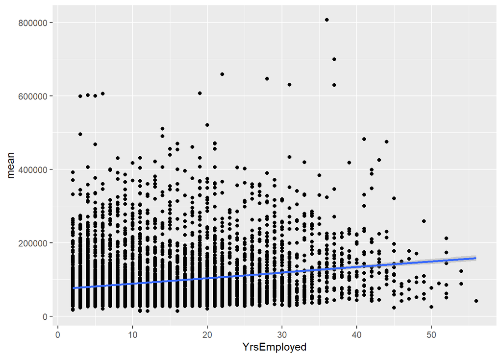

```r
#
ggplot(data = dept_yearsummary, mapping = aes(x = YrsEmployed, y = mean)) + geom_point() + geom_smooth(method = "lm")
```

Answer *(2 Points)*: Based on the scatterplot above and the linear regression line, it appears that there is a weak positive correlation between the salary a UNC employee makes and how many years that employee has served. This is best illustrated by the fact that, based on the data points in the plot above, the average salary of employees varies significantly no matter how many years they have been employed.

###Q12 *(6 Points)*

The purpose of summarizing the data was to analyze the previously discussed linear relationship by group. In `deptyear_summary`, there are 702 unique departments represented. You can verify this by using `length(unique(deptyear_summary$Department))`. In this part, I want you to select 3 academic departments, not previously discussed, and in one figure, display the scatter plots and fitted regression lines representing the relationship between average salary and years employed in three different colors. Then, in complete sentences, I want you to state what departments you chose and explain the differences and/or similarities between the groups regarding the previously mentioned relationship. Compare departments on the starting salary and the rate of increase in salary based on the fitted lines.

Code and Figure: *(3 Points)*:

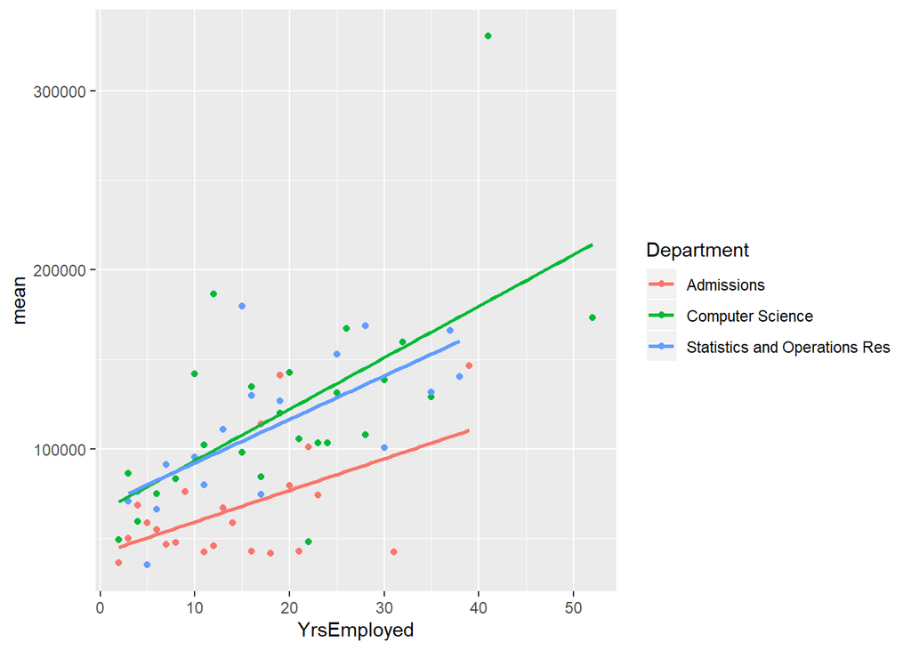

```r
#
departsum = dept_yearsummary %>% filter(Department == "Admissions" | Department == "Statistics and Operations Res" | Department == "Computer Science")

ggplot(departsum, mapping = aes (x = YrsEmployed, y = mean)) + geom_point(mapping = aes(color = Department)) + geom_smooth(method="lm", se=FALSE, mapping = aes(color = Department))
```